# Homework #3.1

```python
%matplotlib inline
import math
import pandas as pd
import matplotlib.pyplot as plt
import statsmodels.api as sm

from sklearn.metrics import r2_score
```

```python
# read data
securities = pd.read_excel('data/hw_3_1_data.xlsx', sheet_name='security returns')
portfolio = pd.read_excel('data/hw_3_1_data.xlsx', sheet_name='portfolio returns')
data = pd.merge(securities, portfolio, on='Date')
```

# 1. Regression

### 1. Estimation of regression of the portfolio return on SPY

```python
# Define and train model
y = data.portfolio
X = data.SPY
model = sm.OLS(y, sm.add_constant(X))
results = model.fit()
results.summary()
```

OLS Regression Results

| Dep. Variable: | portfolio | R-squared: | 0.745 |
| --- | --- | --- | --- |
| Model: | OLS | Adj. R-squared: | 0.743 |
| Method: | Least Squares | F-statistic: | 455.5 |
| Date: | Sat, 18 Jun 2022 | Prob (F-statistic): | 3.93e-48 |
| Time: | 22:42:52 | Log-Likelihood: | 443.21 |
| No. Observations: | 158 | AIC: | -882.4 |
| Df Residuals: | 156 | BIC: | -876.3 |
| Df Model: | 1 |  |  |
| Covariance Type: | nonrobust |  |  |

|  | coef | std err | t | P>\|t\| | [0.025 | 0.975] |
| --- | --- | --- | --- | --- | --- | --- |
| const | -0.0006 | 0.001 | -0.479 | 0.633 | -0.003 | 0.002 |
| SPY | 0.6142 | 0.029 | 21.342 | 0.000 | 0.557 | 0.671 |

| Omnibus: | 21.658 | Durbin-Watson: | 1.946 |
| --- | --- | --- | --- |
| Prob(Omnibus): | 0.000 | Jarque-Bera (JB): | 65.437 |
| Skew: | 0.448 | Prob(JB): | 6.17e-15 |
| Kurtosis: | 6.023 | Cond. No. | 24.6 |

Notes:  
[1] Standard Errors assume that the covariance matrix of the errors is correctly specified.

From the summary we have: </br> $\alpha = -6*10^{-4}$ </br> $\beta = 0.6142$ </br> $R^{2} = 0.745$ </br>

### 2. Estimation of regression of portfolio on SPY and HYG

```python
# Define and train model
X =  data[['SPY', 'HYG']]
model = sm.OLS(y, sm.add_constant(X))
results = model.fit()
results.summary()
```

OLS Regression Results

| Dep. Variable: | portfolio | R-squared: | 0.832 |
| --- | --- | --- | --- |
| Model: | OLS | Adj. R-squared: | 0.830 |
| Method: | Least Squares | F-statistic: | 384.2 |
| Date: | Sat, 18 Jun 2022 | Prob (F-statistic): | 8.57e-61 |
| Time: | 22:42:52 | Log-Likelihood: | 476.28 |
| No. Observations: | 158 | AIC: | -946.6 |
| Df Residuals: | 155 | BIC: | -937.4 |
| Df Model: | 2 |  |  |
| Covariance Type: | nonrobust |  |  |

|  | coef | std err | t | P>\|t\| | [0.025 | 0.975] |
| --- | --- | --- | --- | --- | --- | --- |
| const | -0.0009 | 0.001 | -0.915 | 0.362 | -0.003 | 0.001 |
| SPY | 0.3843 | 0.035 | 11.072 | 0.000 | 0.316 | 0.453 |
| HYG | 0.5166 | 0.058 | 8.977 | 0.000 | 0.403 | 0.630 |

| Omnibus: | 1.294 | Durbin-Watson: | 2.246 |
| --- | --- | --- | --- |
| Prob(Omnibus): | 0.524 | Jarque-Bera (JB): | 1.296 |
| Skew: | 0.214 | Prob(JB): | 0.523 |
| Kurtosis: | 2.886 | Cond. No. | 66.9 |

Notes:  
[1] Standard Errors assume that the covariance matrix of the errors is correctly specified.

From the summary we have: </br> $\alpha = -9*10^{-4}$ </br> $\tilde{\beta}^{spy} = 0.3843$ </br> $\tilde{\beta}^{hyg} = 0.5166$ </br> $R^{2} = 0.832$ </br>

### 3. Time series of fitted regression

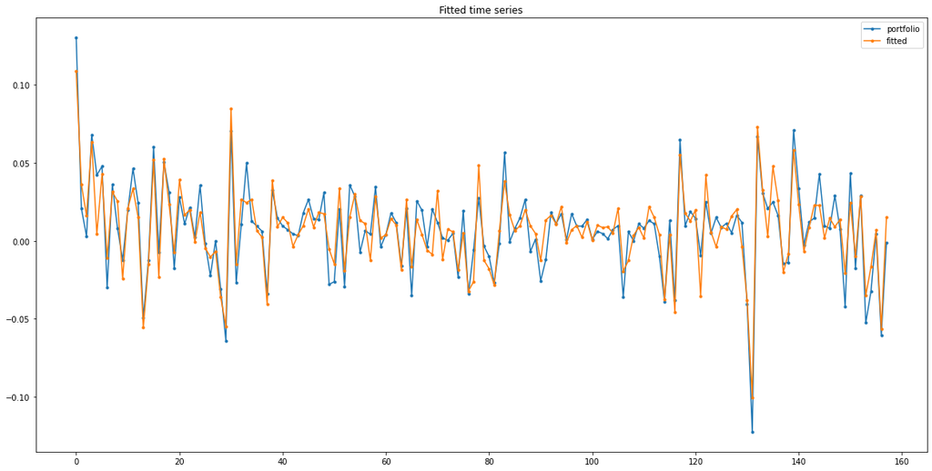

```python
fitted = pd.concat([y, pd.DataFrame(data=results.predict(sm.add_constant(X)), index=X.index, columns=['fitted'])],axis=1)
fitted.plot(title='Fitted time series', figsize=(20, 10), marker='.')
```

### Correlation between $\hat{r}^{p}_{t}$ and $r^{p}_{t}$

```python
fitted.corr()['fitted'].iloc[0]
```

```
0.9122188135325914
```

The r-squared of the regression in equation $(2)$ is **0.832**, which is squared correlation.  
$R^{2} = corr(\hat{r}^{p}_{t}, r^{p}_{t})^2$  
$0.912^2 = 0.832$

### 4.

```python
data[['SPY', 'HYG']].corr()['SPY'].iloc[1]
```

```
0.7380170112481026
```

$\beta^{spy}=0.6142$ in $(1)$ and $\tilde{\beta}^{spy}=0.3843$ in $(2)$. Hence, $\beta^{spy}$ is greater than $\tilde{\beta}^{spy}$</br> The correlation between SPY and HYG is 0.738, which is fairly high. This means that the addition of HYG as a regressor "dilutes" the contribution of SPY given the high correlation between both regressors.

### 5.

$\epsilon_{t}$ should have higher correlation with $r_{t}^{hyg}$ because the contribution of HYG isn't accounted for in equation $(1)$